# Speed comparisons of graph drawing packages

Samantha Tyner, François Briatte, and Heike Hofmann

2016-10-19

# Introduction

This vignette provides access to the online supplement to the paper `` Network Visualization with `ggplot2` ``.

The code to access data for all of the examples and to reproduce all of the figures is available at tyner-briatte-hofmann.R.

A summary of the speed comparisons is shown in the paper. A more detailed outline together with the code to reproduce findings is given in the next section.

# Speed Comparisons

This vignette compares the speeds of our package to the other `ggplot2`-based network visualization package `ggnetwork`, the `GGally` function `ggnet2()`, and the visualization capabilities of the `igraph` and `network` packages.

## Speed Comparison 1

In this first example, we visualize the protein-protein interaction network in the yeast species *S. cerevisiae* using several different methods.

First, load all of the necessary packages and data sets.

```r
## igraph (current: v1.0.1)
if (!require(igraph, quietly = TRUE)) {
  install.package("igraph")
}
library(igraph)

## network (current: v1.13.0)
if (!require(network, quietly = TRUE)) {
  install.package("network")
}
library(network)

## ggnet2
if (!require(GGally, quietly = TRUE)) {
  install.packages("GGally")
}
library(GGally)

## geom_net
library(geomnet) # also currently requires dplyr

## ggnetwork
if (!require(ggnetwork, quietly = TRUE)) {
  install.packages("ggnetwork")
}
library(ggnetwork)

## pre-loading
library(sna)
```

```r
## ggplot2
library(ggplot2)

## other packages
library(dplyr)
library(tidyr)

## load data
data(protein, package = "geomnet")
```

Next, generate the network visualization of this network 100 times using the random layout option in each package and store the time to plot each run.

```r
d = data.frame()

if (!file.exists("runtimes-protein-100.csv")) {

  for (i in 1:100) {

    cat("Iteration", sprintf("%3.0f", i), "/ 100\n")

    n = as.matrix(protein$edges[, 1:2])
    n = igraph::graph_from_edgelist(n, directed = FALSE)

    t1 = system.time({
      plot(n, vertex.label = NA, layout = layout_randomly)
    })[1]

    n = network(protein$edges[, 1:2], directed = FALSE)

    t2 = system.time({
     plot(n, coord = gplot.layout.random(n, NULL))
    })[1]

    t3 = system.time({
      print(ggnet2(n, mode = "random"))
    })[1]

    t4 = system.time({
      print(ggplot(data = protein$edges, aes(from_id = from, to_id = to)) +
              geom_net(layout = "random"))
    })[1]

    t5 = system.time({
      print(ggplot(ggnetwork(n, layout = "random"),
                   aes(x, y, xend = xend, yend = yend)) +
              geom_edges() +
              geom_nodes())
    })[1]

    d = rbind(d, data.frame(
      iteration = i,
      igraph = t1,
      network = t2,
      ggnet2 = t3,
      geomnet = t4,
      ggnetwork = t5,
      row.names = NULL
    ))

  }

  write.csv(d, file = "runtimes-protein-100.csv", row.names = FALSE)

}
```

Finally, compare the 100 runtimes for each method side-by-side. In the resulting plot below, we use our own data, which can be found [here](https://raw.githubusercontent.com/sctyner/ggnet-paper/master/runtimes-protein/runtimes-protein-100.csv).

```r
link_to_data <- "runtimes-protein-100.csv"
g = read.csv(link_to_data, stringsAsFactors = FALSE) %>%
      gather(`Visualization approach`, time, -iteration)
```

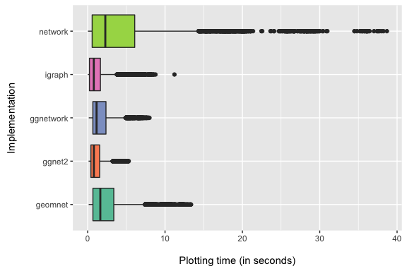

```r
ggplot(g, aes(x = `Visualization approach`, y = time,
              fill = `Visualization approach`)) +
  geom_boxplot() +
  scale_fill_brewer(palette = "Set2") +
  coord_flip() +
  labs(y = "\nPlotting time (in seconds)", x = "Implementation\n") +
  guides(fill = FALSE)
```

# Speed Comparison 2

The figure summarizes the results of these benchmarks using a convenience sample of machines accessible to the authors, including authors’ hardware and additional results from friends’ and colleagues’ machines. The data containing runtimes of for all of these machines can be found [here](https://github.com/sctyner/ggnet-paper/tree/master/runtimes).

This time, we visualize graphs of various sizes that we generated randomly with edge probability 0.2 using the `sna` package. The sizes we generated are overall fairly small, from 25 to 250 nodes, going up by 25 each time. Each network visualization method was test 100 times in total for each size of network.

```r
# note: plot.network might be slower because it actually prints the plots, so to
# compare the methods, we need to evaluate the ggplot plots by printing them too

# create 10 files per size
for (k in 0:9) {

  # the 10 different sizes
  for (i in seq(250, 25, -25)) {

    f = paste0("runtimes-", sprintf("%04.0f", i), "-", k, ".csv")

    if (!file.exists(f)) {

      d = data.frame()

      # in each file store the runtimes of plotting 10 random graphs
      # do this for each of the 5 methods
      for (j in 1:10) {

        r = sna::rgraph(i, tprob = 0.2)

        cat("Network size", i,
            "iteration", sprintf("%3.0f", 10 * k + j), "/ 100\n")

        n = igraph::graph_from_adjacency_matrix(r, mode = "undirected")

        t1 = system.time({
          plot(n, vertex.label = NA)
        })[1]

        n = network::network(r, directed = FALSE)

        t2 = system.time({
          plot.network(n)
        })[1]

        t3 = system.time({
          print(ggnet2(n))
        })[1]

        e = data.frame(sna::as.edgelist.sna(n))

        t4 = system.time({
          print(ggplot(data = e) +
                  geom_net(aes(from_id = X1, to_id = X2)))
        })[1]

        t5 = system.time({
          print(ggplot(ggnetwork(n),
                       aes(x, y, xend = xend, yend = yend)) +
                  geom_edges() +
                  geom_nodes())
        })[1]

        d = rbind(d, data.frame(
          network_size = i,
          iteration = 10 * k + j,
          igraph = t1,
          network = t2,
          ggnet2 = t3,
          geomnet = t4,
          ggnetwork = t5,
          row.names = NULL
        ))

        dev.off()

      }

      write.csv(d, f, row.names = FALSE)

    }

  }
```

Again, for this plot we use our data that is available on Github. Network sizes are plotted horizontally, execution times of 100 runs under each visualization approach are plotted on the $y$-axis. Each panel shows a different machine as indicated by the facet label. Note that each panel is scaled separately to account for differences in the overall speed of these machines.

```r
# get all files containing runtime information and combine them into a single data frame.
g = list.files(pattern = "runtimes-(.*)csv$") %>%
        lapply(read.csv, stringsAsFactors = FALSE) %>%
        bind_rows %>%
        gather(`Visualization approach`, time, -network_size, -iteration) %>%
        group_by(network_size, `Visualization approach`) %>%
        summarise(mean_time = mean(time),
                  q05 = quantile(time, 0.05),
                  q95 = quantile(time, 0.95))
```

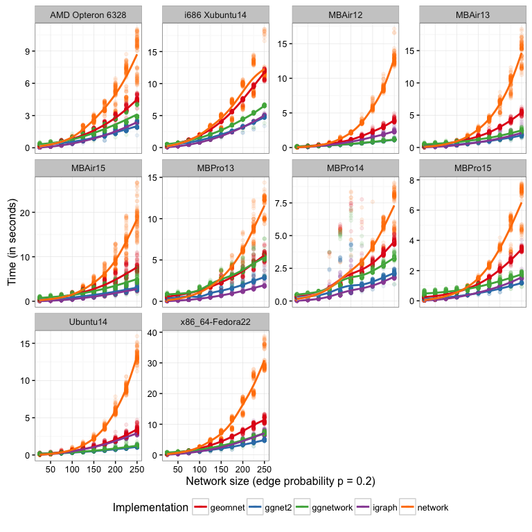

What these plots indicate is that we have surprisingly large variability in relative run times across different machines. However, the results support some general findings.

The plotting routine in the network package is by far the slowest across all machines, while the plotting with `igraph` is generally among the fastest. Our three approaches generally feature in between these two, with `ggnet2` being as fast or faster than `igraph` plotting, followed by `ggnetwork` and `geomnet`, which is generally the slowest among the three. These differences become more pronounced as the size of the network increases.